# ME906 - Métodos em Aprendizado Supervisionado de Máquina

Atividade 02

```r
# Carregue os pacotes aqui
library(ISLR2)
library(tidymodels)
library(ggpubr)
library(GGally)
library(kableExtra)
library(leaps)
library(tinytex)
```

# Objetivo

Encontrar um bom modelo para predizer a variável `Sales`, baseando-se nas informações disponíveis no conjunto de dados `Carseats`. Apenas modelos de regressão linear (simples ou múltipla) serão considerados.

# Dados

```r
#Carrega o banco de dados
data(Carseats)
#Calcula a correlação entre as variáveis Price e CompPrice
corPrice = cor(Carseats$Price ,Carseats$CompPrice)
```

O conjunto de dados `Carseats`, disponível no pacote `ISLR2`, contém informações de vendas de cadeirinhas de infantis para automóveis de uma determinada marca em 400 lojas diferentes e 11 variáveis:

- `Sales`: unidades de venda em milhares;
- `CompPrice`: preço do competidor (em dólares);
- `Income`: renda média da comunidade local em 1000 dólares;
- `Advertising`: orçamento local para anúncios em 1000 dólares;
- `Population`: população regional em milhares;
- `Price`: preço da cadeirinha em dólares;
- `ShelveLoc`: qualidade da localização do produto na prateleira (Bad, Good ou Medium);
- `Age`: idade média da população local (em anos);
- `Education`: nível médio de educação da população local (em anos);
- `Urban`: fator indicando se a loja está em uma área urbana ou não;
- `US`: fator indicando se a loja é nos EUA ou não.

# Divisão dos dados

```r
#Quebra os niveis da variável ShelveLoc em duas variáveis e padroniza as variáveis númericas
Carseats = Carseats %>%
  mutate(PriceDif = (Price-CompPrice)/1000, ShelveLocGood = factor(case_when(ShelveLoc == "Good" ~ 1, TRUE ~ 0 )), ShelveLocMedium = factor(case_when(ShelveLoc == "Medium" ~ 1, TRUE ~ 0))) %>%
  select(-Price,-CompPrice,-ShelveLoc) %>%
  mutate_if(is.numeric, scale)
```

```r
#Faz a divisão do banco de dados em treino, validação e teste.
set.seed(22021)
split_teste <- initial_split(Carseats, prop=0.8)

#dados teste (dados "do gerente")
teste <- split_teste %>% testing()

# dados treinamento com validação
treino_e_valid <- split_teste %>% training()

split_treino <- initial_split(treino_e_valid, prop=0.75)

#dados treinamento
treino <- split_treino %>% training()

#dados validação
valid <- split_treino %>% testing()
```

# Análise exploratória

No banco de dados `Carseats`, as variáveis `CompPrice` e `Price` representam, respectivamente, o preço de venda da concorrência e o preço de venda da marca em questão em cada uma das lojas do banco de dados. Devido a natureza semelhante dessas duas variáveis e sua alta correlação (coeficiente de correlação de Pearson igual a 0.5848478), elas foram combinadas numa terceira variável chamada `PriceDif`, que descreve a diferença de preço do produto entre marca e a sua principal rival, em dólares, de forma que valores negativos de `PriceDif` indicam o quão mais barato é o valor da cadeirinha em relação à concorrência.

Também foi considerado no banco de dados uma padronização em relação às variáveis numéricas, dado que há uma grande divergência de escala entre as variáveis. Um exemplo dessa divergência seria a variável `Population` em escala de centenas de milhares enquanto que a variável `PriceDif` e `Age` são variaveis em escala de dezenas.

Na Tabela foram calculadas as correlações entre as variáveis numéricas após a padronização:

### Correlação entre as variáveis númericas padronizadas

```r
#Apresenta a tabala de correlação entre as variáveis númericas
kable(cor(keep(Carseats, is.numeric)[2:7,2:7]),caption = "Tabela de correlação entre as variáveis númericas",label = "cor")%>%
  kable_styling(bootstrap_options = c("striped", "hover", "condensed", "responsive"), font_size = 10)
```

Tabela de correlação entre as variáveis númericas

|  | Income | Advertising | Population | Age | Education | PriceDif |
| --- | --- | --- | --- | --- | --- | --- |
| Income | 1.0000000 | -0.3745721 | 0.2149250 | 0.4459586 | 0.8889360 | -0.0320274 |
| Advertising | -0.3745721 | 1.0000000 | 0.3524131 | 0.3923275 | -0.4470247 | -0.7917290 |
| Population | 0.2149250 | 0.3524131 | 1.0000000 | -0.0996404 | 0.2149621 | -0.6255585 |
| Age | 0.4459586 | 0.3923275 | -0.0996404 | 1.0000000 | 0.3648336 | -0.5176228 |
| Education | 0.8889360 | -0.4470247 | 0.2149621 | 0.3648336 | 1.0000000 | -0.1266342 |
| PriceDif | -0.0320274 | -0.7917290 | -0.6255585 | -0.5176228 | -0.1266342 | 1.0000000 |

Como é possível observar na tabela, existe uma alta correlação entre as variáveis `PriceDif` e `Advertising`. Além dessas, também há uma alta correlação entre as variáveis `Education` e `Income`, sendo assim, para evitar quaisquer problemas envolvendo multicolinearidade, destas serão consideradas apenas `PriceDif` e `Income` para a seleção dos modelos de regressão.

```r
#Income e sales
treino_e_valid %>%
  ggplot() +
  geom_point(aes(x=PriceDif,y=Sales), color = "darkorchid2") +
  theme_bw()+
  theme(axis.title.x = element_text(size = 14),
        axis.title.y = element_text(size = 14),
        legend.title = element_text(size=14),
        legend.text = element_text(size=12),
        axis.text.x=element_text(size=12),
        axis.text.y=element_text(size=12)) -> PdfSalPlot

#Income e sales
treino_e_valid %>%
  ggplot() +
  geom_point(aes(x=Income,y=Sales), color = "turquoise2") +
  theme_bw()+
  theme(axis.title.x = element_text(size = 14),
        axis.title.y = element_text(size = 14),
        legend.title = element_text(size=14),
        legend.text = element_text(size=12),
        axis.text.x=element_text(size=12),
        axis.text.y=element_text(size=12)) -> IncSalPlot

#Advertising e sales
#treino_e_valid %>%
  #ggplot() +
  #geom_point(aes(x=Advertising,y=Sales)) +
  #theme_bw() -> AdvSalPlot

#Population e sales
treino_e_valid %>%
  ggplot() +
  geom_point(aes(x=Population,y=Sales), color = "darkgoldenrod") +
  theme_bw()+
  theme(axis.title.x = element_text(size = 14),
        axis.title.y = element_text(size = 14),
        legend.title = element_text(size=14),
        legend.text = element_text(size=12),
        axis.text.x=element_text(size=12),
        axis.text.y=element_text(size=12)) -> PopSalPlot

#Age e sales
treino_e_valid %>%
  ggplot() +
  geom_point(aes(x=Age,y=Sales), color = "darkorange1") +
  theme_bw()+
  theme(axis.title.x = element_text(size = 14),
        axis.title.y = element_text(size = 14),
        legend.title = element_text(size=14),
        legend.text = element_text(size=12),
        axis.text.x=element_text(size=12),
        axis.text.y=element_text(size=12)) -> AgeSalPlot

#Education e sales
#treino_e_valid %>%
  #ggplot() +
  #geom_point(aes(x=Education,y=Sales)) +
  #theme_bw() -> EduSalPlot

#ShelveLoc1 e sales
treino_e_valid %>%
 group_by(ShelveLocGood) %>%
  summarise(Sales = sum(Sales)) %>%
  ggplot() +
  geom_bar(aes(x=ShelveLocGood,y=Sales), stat = "identity", fill = "deepskyblue1", colour="darkblue") +
  theme_bw()+
  theme(axis.title.x = element_text(size = 14),
        axis.title.y = element_text(size = 14),
        legend.title = element_text(size=14),
        legend.text = element_text(size=12),
        axis.text.x=element_text(size=12),
        axis.text.y=element_text(size=12)) -> Slc1SalPlot

#ShelveLoc2 e sales
treino_e_valid %>%
 group_by(ShelveLocMedium) %>%
  summarise(Sales = sum(Sales)) %>%
  ggplot() +
  geom_bar(aes(x=ShelveLocMedium,y=Sales), stat = "identity", fill = "khaki2", colour="yellow") +
  theme_bw()+
  theme(axis.title.x = element_text(size = 14),
        axis.title.y = element_text(size = 14),
        legend.title = element_text(size=14),
        legend.text = element_text(size=12),
        axis.text.x=element_text(size=12),
        axis.text.y=element_text(size=12)) -> Slc2SalPlot

#Urban e sales
treino_e_valid %>%
  group_by(Urban) %>%
  summarise(Sales = sum(Sales)) %>%
  ggplot() +
  geom_bar(aes(x=Urban,y=Sales), stat = "identity", fill = "pink", colour = "red") +
  theme_bw()+
  theme(axis.title.x = element_text(size = 14),
        axis.title.y = element_text(size = 14),
        legend.title = element_text(size=14),
        legend.text = element_text(size=12),
        axis.text.x=element_text(size=12),
        axis.text.y=element_text(size=12)) -> UbnSalPlot

#US e sales
treino_e_valid %>%
  group_by(US) %>%
  summarise(Sales = sum(Sales)) %>%
  ggplot() +
  geom_bar(aes(x=US,y=Sales), stat = "identity", fill = "lightgreen", colour ="green4") +
  theme_bw()+
  theme(axis.title.x = element_text(size = 14),
        axis.title.y = element_text(size = 14),
        legend.title = element_text(size=14),
        legend.text = element_text(size=12),
        axis.text.x=element_text(size=12),
        axis.text.y=element_text(size=12)) -> UsSalPlot
```

### Distribuição das variáveis numéricas em relação a variável reposta `Sales`

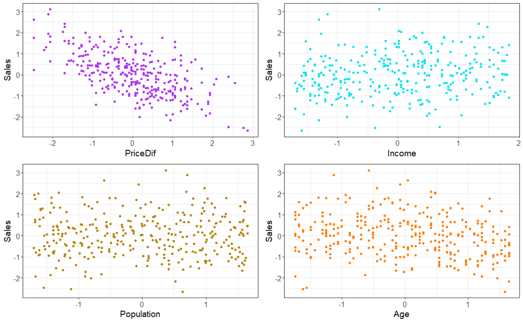

```r
ggarrange(plotlist = list(PdfSalPlot, IncSalPlot, PopSalPlot, AgeSalPlot))
```

### Distribuição das variáveis categóricas em relação a variável reposta `Sales`

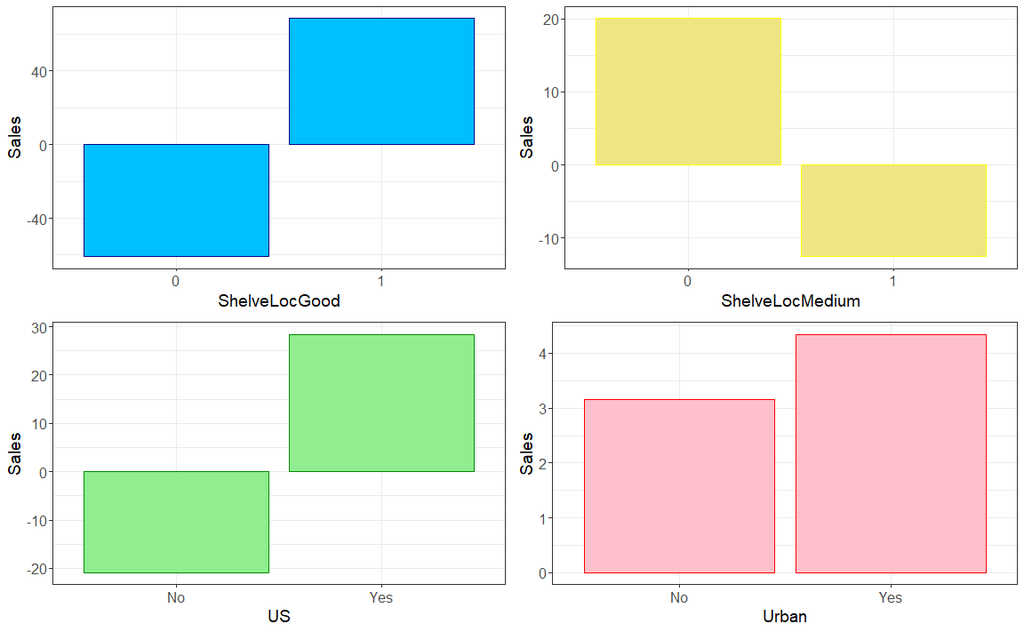

```r
ggarrange(plotlist = list(Slc1SalPlot, Slc2SalPlot, UsSalPlot, UbnSalPlot), ncol = 2, nrow = 2)
```

A Figura permite observar visualmente como as covariáveis numéricas se relacionam com a variável resposta. Nota-se que há forte relação entre `PriceDif` e `Sales`: à medida que o produto da marca em questão é mais barato que o concorrente, há mais vendas, e vice versa. As demais não apresentam forte associação com a variável `Sales`.

Segundo a Figura , há grande diferença nas vendas de acordo com o nível das variáveis categóricas `ShelveLocGood`, `ShelveLocMedium` e `US`. Ou seja, estar numa posição boa, não estar numa posição média na prateleira, ou estar numa loja localizada nos Estados Unidos está associado a altos valores em `Sales`. A variável `Urban` não apresenta visualmente uma forte relação com a resposta.

# Avaliação de modelos propostos

Foram considerados então todos os 2^8-1=255 possíveis modelos de regressão linear (simples e múltipla) ajustados ao banco de dados de treino, os quais são apresentados na tabela a seguir:

### Coleção de Modelos ajustados e os respectivos EQM de Treino e Validação

```r
#Ajusta todos os modelos 1 a 1 para cada variavel preditora
restreino = regsubsets(Sales ~.- Advertising-Education, data = treino, nbest= 70, nvmax = 8, really.big = T)

#Sumarisa os resultados do regsubsets
sumrt = summary(restreino)


predict.regsubsets = function(object, newdata, id, ...) {
    form = as.formula(object$call[[2]])
    mat = model.matrix(form, newdata)
    coefi = coef(object, id = id)
    mat[, names(coefi)] %*% coefi
}

EQM_Valid = rep(0,nrow(sumrt$which))
for (i in 1:nrow(sumrt$which)) {
  EQM_Valid[i] = (sum((predict.regsubsets(restreino, valid, i)-valid$Sales)^2)/nrow(valid))

}

EQMs = cbind(Modelo = c(paste("Modelo", c(1:nrow(sumrt$which)))),sumrt$which,
            EQM_Treino = format((sumrt$rss/nrow(treino)),digit=3), EQM_Valid =format(EQM_Valid, digits = 3))

#Expressa a tabela com o
kable(EQMs) %>%
  kable_styling(bootstrap_options = c("striped", "hover", "condensed", "responsive"), font_size = 10) %>%
  scroll_box(height = "400px")
```

|  | Modelo | (Intercept) | Income | Population | Age | UrbanYes | USYes | PriceDif | ShelveLocGood1 | ShelveLocMedium1 | EQM_Treino | EQM_Valid |
| --- | --- | --- | --- | --- | --- | --- | --- | --- | --- | --- | --- | --- |
| 1 | Modelo 1 | TRUE | FALSE | FALSE | FALSE | FALSE | FALSE | TRUE | FALSE | FALSE | 0.621 | 0.613 |
| 1 | Modelo 2 | TRUE | FALSE | FALSE | FALSE | FALSE | FALSE | FALSE | TRUE | FALSE | 0.772 | 0.644 |
| 1 | Modelo 3 | TRUE | FALSE | FALSE | TRUE | FALSE | FALSE | FALSE | FALSE | FALSE | 0.946 | 0.919 |
| 1 | Modelo 4 | TRUE | TRUE | FALSE | FALSE | FALSE | FALSE | FALSE | FALSE | FALSE | 0.955 | 0.961 |
| 1 | Modelo 5 | TRUE | FALSE | FALSE | FALSE | FALSE | TRUE | FALSE | FALSE | FALSE | 0.957 | 0.971 |
| 1 | Modelo 6 | TRUE | FALSE | FALSE | FALSE | FALSE | FALSE | FALSE | FALSE | TRUE | 0.977 | 0.961 |
| 1 | Modelo 7 | TRUE | FALSE | TRUE | FALSE | FALSE | FALSE | FALSE | FALSE | FALSE | 0.985 | 0.981 |
| 1 | Modelo 8 | TRUE | FALSE | FALSE | FALSE | TRUE | FALSE | FALSE | FALSE | FALSE | 0.986 | 0.979 |
| 2 | Modelo 9 | TRUE | FALSE | FALSE | FALSE | FALSE | FALSE | TRUE | TRUE | FALSE | 0.336 | 0.344 |
| 2 | Modelo 10 | TRUE | FALSE | FALSE | TRUE | FALSE | FALSE | TRUE | FALSE | FALSE | 0.552 | 0.570 |
| 2 | Modelo 11 | TRUE | FALSE | FALSE | FALSE | FALSE | TRUE | TRUE | FALSE | FALSE | 0.588 | 0.575 |
| 2 | Modelo 12 | TRUE | TRUE | FALSE | FALSE | FALSE | FALSE | TRUE | FALSE | FALSE | 0.601 | 0.578 |
| 2 | Modelo 13 | TRUE | FALSE | FALSE | FALSE | FALSE | FALSE | TRUE | FALSE | TRUE | 0.605 | 0.597 |
| 2 | Modelo 14 | TRUE | FALSE | TRUE | FALSE | FALSE | FALSE | TRUE | FALSE | FALSE | 0.619 | 0.611 |
| 2 | Modelo 15 | TRUE | FALSE | FALSE | FALSE | TRUE | FALSE | TRUE | FALSE | FALSE | 0.621 | 0.619 |
| 2 | Modelo 16 | TRUE | FALSE | FALSE | FALSE | FALSE | FALSE | FALSE | TRUE | TRUE | 0.719 | 0.575 |
| 2 | Modelo 17 | TRUE | FALSE | FALSE | TRUE | FALSE | FALSE | FALSE | TRUE | FALSE | 0.742 | 0.579 |
| 2 | Modelo 18 | TRUE | TRUE | FALSE | FALSE | FALSE | FALSE | FALSE | TRUE | FALSE | 0.743 | 0.639 |
| 2 | Modelo 19 | TRUE | FALSE | FALSE | FALSE | FALSE | TRUE | FALSE | TRUE | FALSE | 0.754 | 0.646 |
| 2 | Modelo 20 | TRUE | FALSE | TRUE | FALSE | FALSE | FALSE | FALSE | TRUE | FALSE | 0.771 | 0.648 |
| 2 | Modelo 21 | TRUE | FALSE | FALSE | FALSE | TRUE | FALSE | FALSE | TRUE | FALSE | 0.772 | 0.644 |
| 2 | Modelo 22 | TRUE | FALSE | FALSE | TRUE | FALSE | TRUE | FALSE | FALSE | FALSE | 0.909 | 0.927 |
| 2 | Modelo 23 | TRUE | TRUE | FALSE | TRUE | FALSE | FALSE | FALSE | FALSE | FALSE | 0.916 | 0.899 |
| 2 | Modelo 24 | TRUE | TRUE | FALSE | FALSE | FALSE | TRUE | FALSE | FALSE | FALSE | 0.930 | 0.958 |
| 2 | Modelo 25 | TRUE | FALSE | FALSE | TRUE | FALSE | FALSE | FALSE | FALSE | TRUE | 0.940 | 0.900 |
| 2 | Modelo 26 | TRUE | FALSE | TRUE | TRUE | FALSE | FALSE | FALSE | FALSE | FALSE | 0.946 | 0.920 |
| 2 | Modelo 27 | TRUE | FALSE | FALSE | TRUE | TRUE | FALSE | FALSE | FALSE | FALSE | 0.946 | 0.919 |
| 2 | Modelo 28 | TRUE | TRUE | FALSE | FALSE | FALSE | FALSE | FALSE | FALSE | TRUE | 0.950 | 0.945 |
| 2 | Modelo 29 | TRUE | FALSE | FALSE | FALSE | FALSE | TRUE | FALSE | FALSE | TRUE | 0.952 | 0.956 |
| 2 | Modelo 30 | TRUE | TRUE | TRUE | FALSE | FALSE | FALSE | FALSE | FALSE | FALSE | 0.954 | 0.964 |

[output cut: 225 more lines]

A tabela também apresenta o EQM de cada modelo referente aos dados de treino e aos dados de validação.

### Distribuição dos EQM de treino em função dos Modelos ajustados,

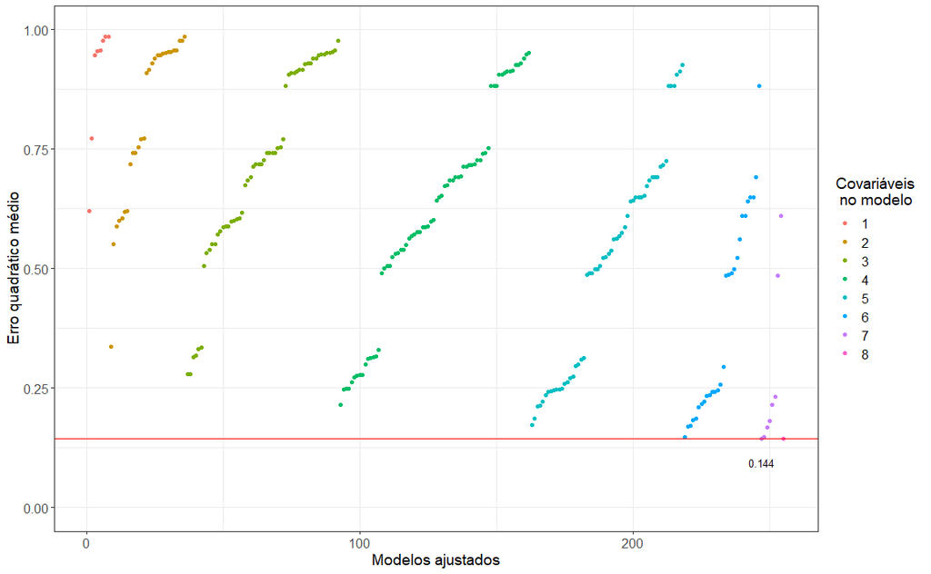

```r
ggplot() +
  geom_point(aes(x=1:255, y=as.numeric(as.data.frame(EQMs)$EQM_Treino), color= row.names(EQMs)))  +
  geom_hline(aes(yintercept = min(as.numeric(as.data.frame(EQMs)$EQM_Treino))), colour = "red", show.legend = FALSE) +
  geom_text(aes(x=247,y=-0.05+min(as.numeric(as.data.frame(EQMs)$EQM_Treino)),label=min(as.numeric(as.data.frame(EQMs)$EQM_Treino))), size = 3.5) +
  scale_y_continuous(limits = c(0,1))+
  labs(x = "Modelos ajustados", y = "Erro quadrático médio", color = "Covariáveis \n no modelo") +
  theme_bw()+
  theme(axis.title.x = element_text(size = 14),
        axis.title.y = element_text(size = 14),
        legend.title = element_text(size=14),
        legend.text = element_text(size=12),
        axis.text.x=element_text(size=12),
        axis.text.y=element_text(size=12))
```

Entretanto, ao aplicar cada um dos modelos ao banco de dados de validação, esses EQMs mudam e é possivel observar uma dispersão diferente dos pontos e, consequentemente, o modelo com o menor EQM observado para o conjunto de validação é outro

### Distribuição dos EQM de validação em função dos modelos ajustados.

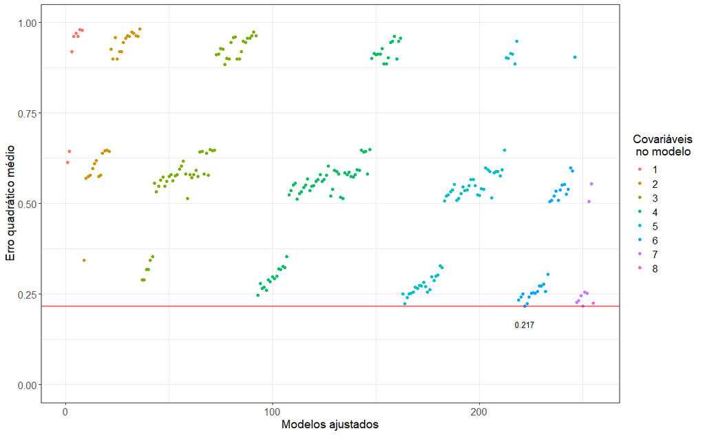

```r
ggplot() +
  geom_point(aes(x=1:255, y=as.numeric(as.data.frame(EQMs)$EQM_Valid), color= row.names(EQMs)))  +
  geom_hline(aes(yintercept = min(as.numeric(as.data.frame(EQMs)$EQM_Valid))), colour = "red", show.legend = FALSE) +
  geom_text(aes(x=222,y=-0.05+min(as.numeric(as.data.frame(EQMs)$EQM_Valid)),label=min(as.numeric(as.data.frame(EQMs)$EQM_Valid))), size = 3.5) +
  scale_y_continuous(limits = c(0,1))+
  labs(x = "Modelos ajustados", y = "Erro quadrático médio", color = "Covariáveis \n no modelo") +
  theme_bw()+
  theme(axis.title.x = element_text(size = 14),
        axis.title.y = element_text(size = 14),
        legend.title = element_text(size=14),
        legend.text = element_text(size=12),
        axis.text.x=element_text(size=12),
        axis.text.y=element_text(size=12))
```

Nesse cenário, o Modelo 222 é o modelo com o menor EQM na validação, e é o escolhido como modelo final.

### Modelo Final

```r
modelo_final = as.data.frame(EQMs)$Modelo[which.min(as.data.frame(EQMs)$EQM_Treino)]
Modelo = lm(Sales ~.- Advertising -Education -Urban -US, data = treino_e_valid)
EQM_Final = mean(Modelo$residuals ^2)
EQM_Final_teste = mean((teste$Sales - predict(Modelo, newdata = teste))^2)
```

O modelo final encontrado foi `Y = -0.72 + 0.16X1 +0.07X2 - 0.24X3 - 0.64X4 + 1.7X5 + 0.65X6`, em que `X1`, `X2` , `X3`, `X4`, `X5` e `X6` representam respectivamente as variáveis `Income`, `Population`, `Age`, `PriceDif`, `ShelveLocGood` e `ShelveLocMedium` padronizadas. Esse modelo ajustado retornou um erro quadrático médio de 0.19 em relação ao banco de dados de treino e validação. Utilizando os coeficientes encontrados, o modelo foi aplicado aos dados de teste, passando a apresentar um EQM de 0.215.